# msleep

Autogenerated data summary from dataMaid

2021-02-24 20:08:49

# Data report overview

The dataset examined has the following dimensions:

| Feature | Result |
| --- | --- |
| Number of observations | 83 |
| Number of variables | 11 |

### Checks performed

The following variable checks were performed, depending on the data type of each variable:

|  | character | factor | labelled | haven labelled | numeric | integer | logical | Date |
| --- | --- | --- | --- | --- | --- | --- | --- | --- |
| Identify miscoded missing values | × | × | × | × | × | × |  | × |
| Identify prefixed and suffixed whitespace | × | × | × | × |  |  |  |  |
| Identify levels with < 6 obs. | × | × | × | × |  |  |  |  |
| Identify case issues | × | × | × | × |  |  |  |  |
| Identify misclassified numeric or integer variables | × | × | × | × |  |  |  |  |
| Identify outliers |  |  |  |  | × | × |  | × |

Please note that all numerical values in the following have been rounded to 2 decimals.

# Summary table

[output not shown]

# Variable list

## name

- The variable is a key (distinct values for each observation).

## genus

| Feature | Result |
| --- | --- |
| Variable type | character |
| Number of missing obs. | 0 (0 %) |
| Number of unique values | 77 |
| Mode | "Panthera" |

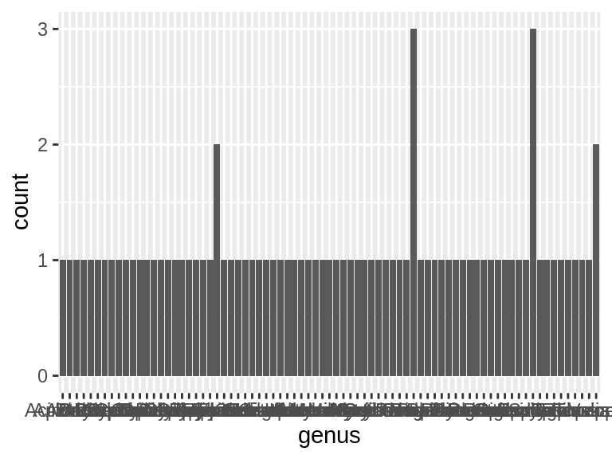

- Note that the following levels have at most five observations: "Acinonyx", "Aotus", "Aplodontia", "Blarina", "Bos", "Bradypus", "Callorhinus", "Calomys", "Canis", "Capreolus" (67 additional values omitted).

## vore

| Feature | Result |
| --- | --- |
| Variable type | character |
| Number of missing obs. | 7 (8.43 %) |
| Number of unique values | 4 |
| Mode | "herbi" |

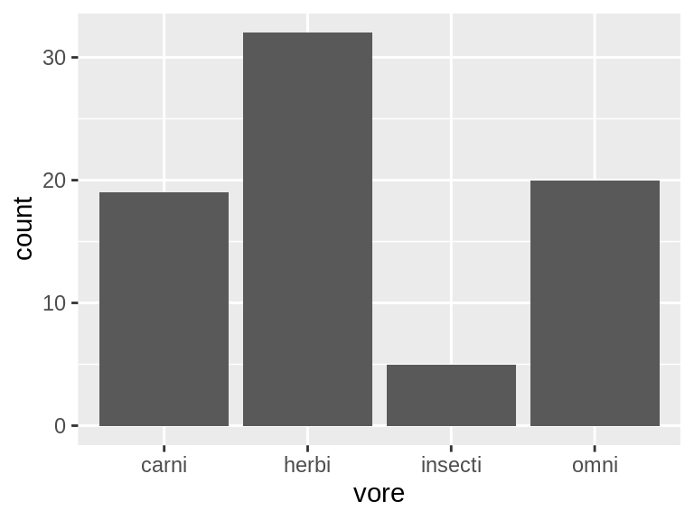

- Note that the following levels have at most five observations: "insecti".

## order

| Feature | Result |
| --- | --- |
| Variable type | character |
| Number of missing obs. | 0 (0 %) |
| Number of unique values | 19 |
| Mode | "Rodentia" |

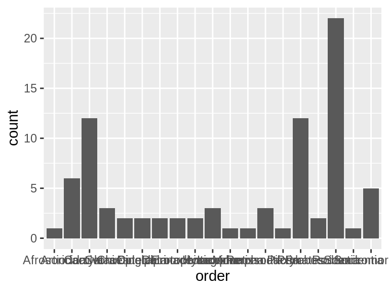

- Note that the following levels have at most five observations: "Afrosoricida", "Cetacea", "Chiroptera", "Cingulata", "Didelphimorphia", "Diprotodontia", "Erinaceomorpha", "Hyracoidea", "Lagomorpha", "Monotremata" (5 additional values omitted).

## conservation

| Feature | Result |
| --- | --- |
| Variable type | character |
| Number of missing obs. | 29 (34.94 %) |
| Number of unique values | 6 |
| Mode | "lc" |

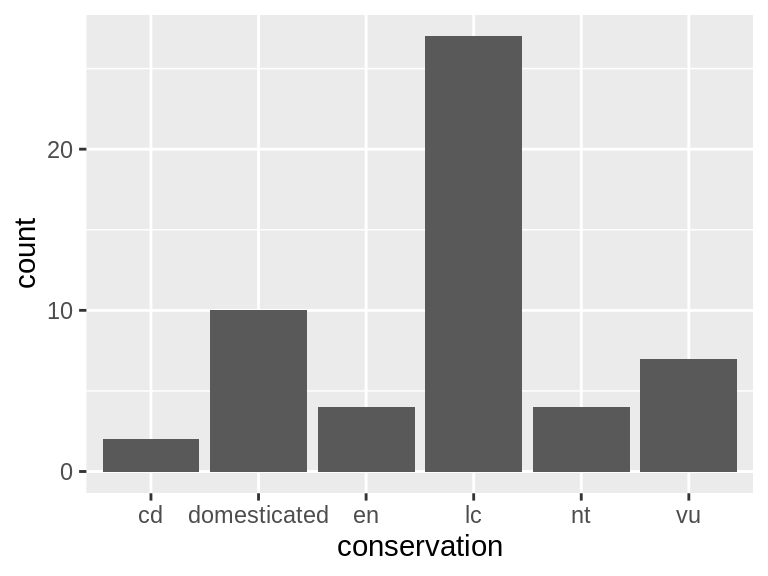

- Note that the following levels have at most five observations: "cd", "en", "nt".

## sleep_total

| Feature | Result |
| --- | --- |
| Variable type | numeric |
| Number of missing obs. | 0 (0 %) |
| Number of unique values | 65 |
| Median | 10.1 |
| 1st and 3rd quartiles | 7.85; 13.75 |
| Min. and max. | 1.9; 19.9 |

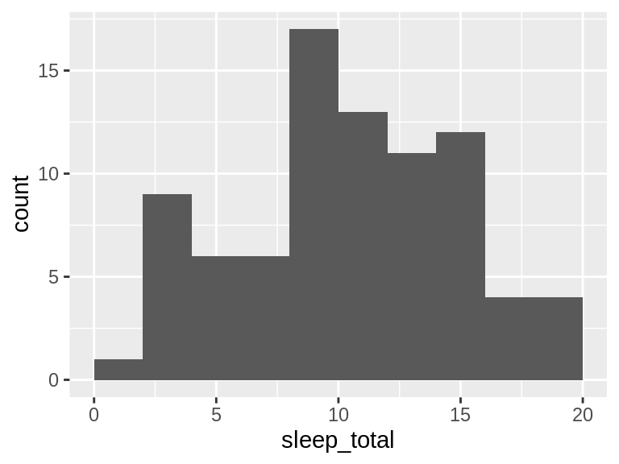

## sleep_rem

| Feature | Result |
| --- | --- |
| Variable type | numeric |
| Number of missing obs. | 22 (26.51 %) |
| Number of unique values | 32 |
| Median | 1.5 |
| 1st and 3rd quartiles | 0.9; 2.4 |
| Min. and max. | 0.1; 6.6 |

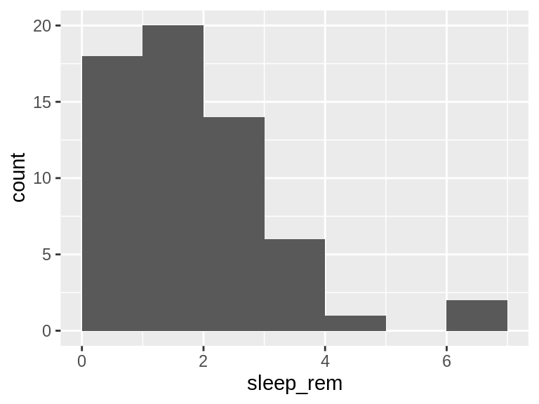

## sleep_cycle

| Feature | Result |
| --- | --- |
| Variable type | numeric |
| Number of missing obs. | 51 (61.45 %) |
| Number of unique values | 22 |
| Median | 0.33 |
| 1st and 3rd quartiles | 0.18; 0.58 |
| Min. and max. | 0.12; 1.5 |

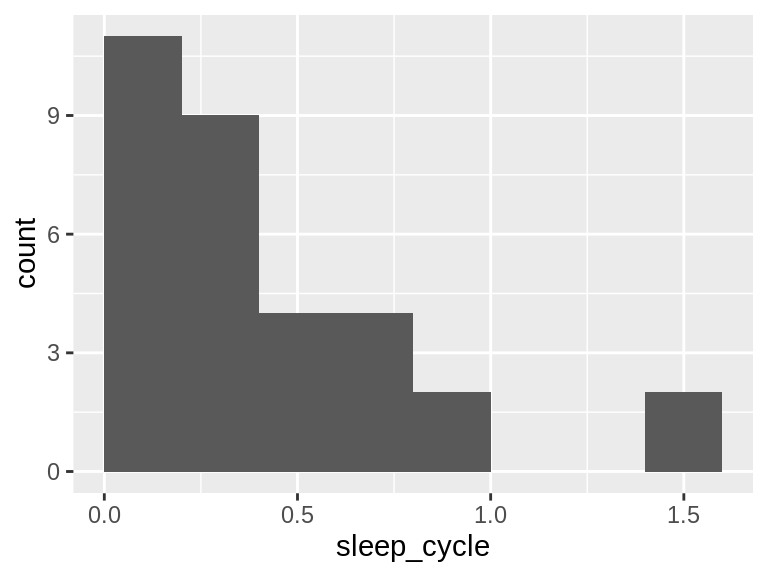

## awake

| Feature | Result |
| --- | --- |
| Variable type | numeric |
| Number of missing obs. | 0 (0 %) |
| Number of unique values | 65 |
| Median | 13.9 |
| 1st and 3rd quartiles | 10.25; 16.15 |
| Min. and max. | 4.1; 22.1 |

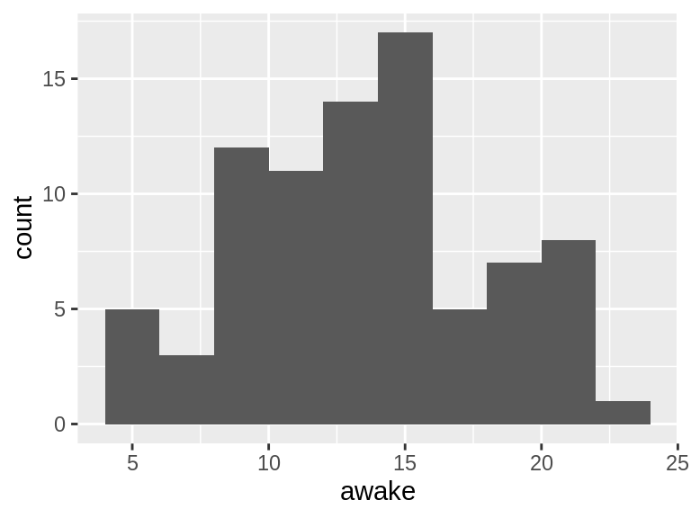

## brainwt

| Feature | Result |
| --- | --- |
| Variable type | numeric |
| Number of missing obs. | 27 (32.53 %) |
| Number of unique values | 53 |
| Median | 0.01 |
| 1st and 3rd quartiles | 0; 0.13 |
| Min. and max. | 0; 5.71 |

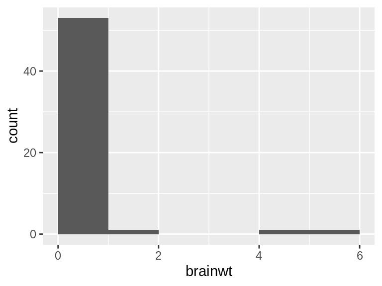

- Note that the following possible outlier values were detected: "4.6", "5.71".

## bodywt

| Feature | Result |
| --- | --- |
| Variable type | numeric |
| Number of missing obs. | 0 (0 %) |
| Number of unique values | 82 |
| Median | 1.67 |
| 1st and 3rd quartiles | 0.17; 41.75 |
| Min. and max. | 0; 6654 |

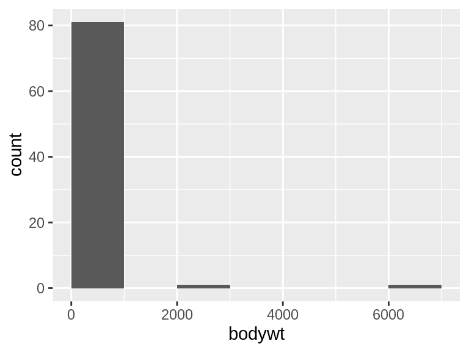

- Note that the following possible outlier values were detected: "2547", "6654".

Report generation information:

- Created by: Could not determine from system (username: `root`).
- Report creation time: Wed Feb 24 2021 20:08:49
- Report was run from directory: `/content`
- dataMaid v1.4.0 [Pkg: 2019-12-10 from CRAN (R 4.0.4)]
- R version 4.0.4 (2021-02-15).
- Platform: x86_64-pc-linux-gnu (64-bit)(Ubuntu 18.04.5 LTS).
- Function call: `makeDataReport(data = msleep)`